# IMAP-PART 03 Downloading and filtering microbiome sequencing data from SRA database

Fostering Reproducible Microbiome data Analysis with Snakemake workflow

Teresia Mrema-Buza

IMAP-PART 03 [Latest GitHub-Repo](https://github.com/tmbuza/imap-download-sra-reads/) Updated on 2023-03-13

# Getting sequencing data from SRA

## Brief Intro

Microlbiome read sequencing data may be obtained from different sources. The most common ones include:

1. Reads directly from a sequencing platforms.
2. Reads downloaded from the Sequence Read Archive (SRA) or the European Nucleotide Archive (ENA).
3. Reads synthesized using sequencing simulators.

## Snakemake workflow rules

[figure not shown]

Tentative snakemake workflow

# Getting ready to download reads from SRA

## Reads from SRA

The NCBI Sequence Read Archive (SRA) stores sequencing data from the next generation sequencing platforms. Users can download data from the SRA archive using the SRA toolkits or custom computational methods.

## Demo Installing SRA Toolkit on Mac OS.

### Download `sratoolkit`

- Navigate to where you want to install the tools, preferably the home directory.
- For more information click [here](https://github.com/ncbi/sra-tools/wiki/02.-Installing-SRA-Toolkit).

```bash
curl -LO  https://ftp-trace.ncbi.nlm.nih.gov/sra/sdk/3.0.0/sratoolkit.3.0.0-mac64.tar.gz
tar -xf sratoolkit.3.0.0-mac64.tar.gz
export PATH=$HOME/sratoolkit.3.0.0-mac64/bin/:$PATH
```

### Create a cache root directory

```bash
mkdir -p ~/ncbi
echo '/repository/user/main/public/root = "cache_directory"' > ~/ncbi/user-settings.mkfg
```

### Confirm sra toolkit configuration

- The `vdb-config -i` command below will display a blue colored dialog.
- Use tab or click `c` to navigate to cache tab.
- Review the configuration then save `s` and exit `x`.

```bash
vdb-config -i
```

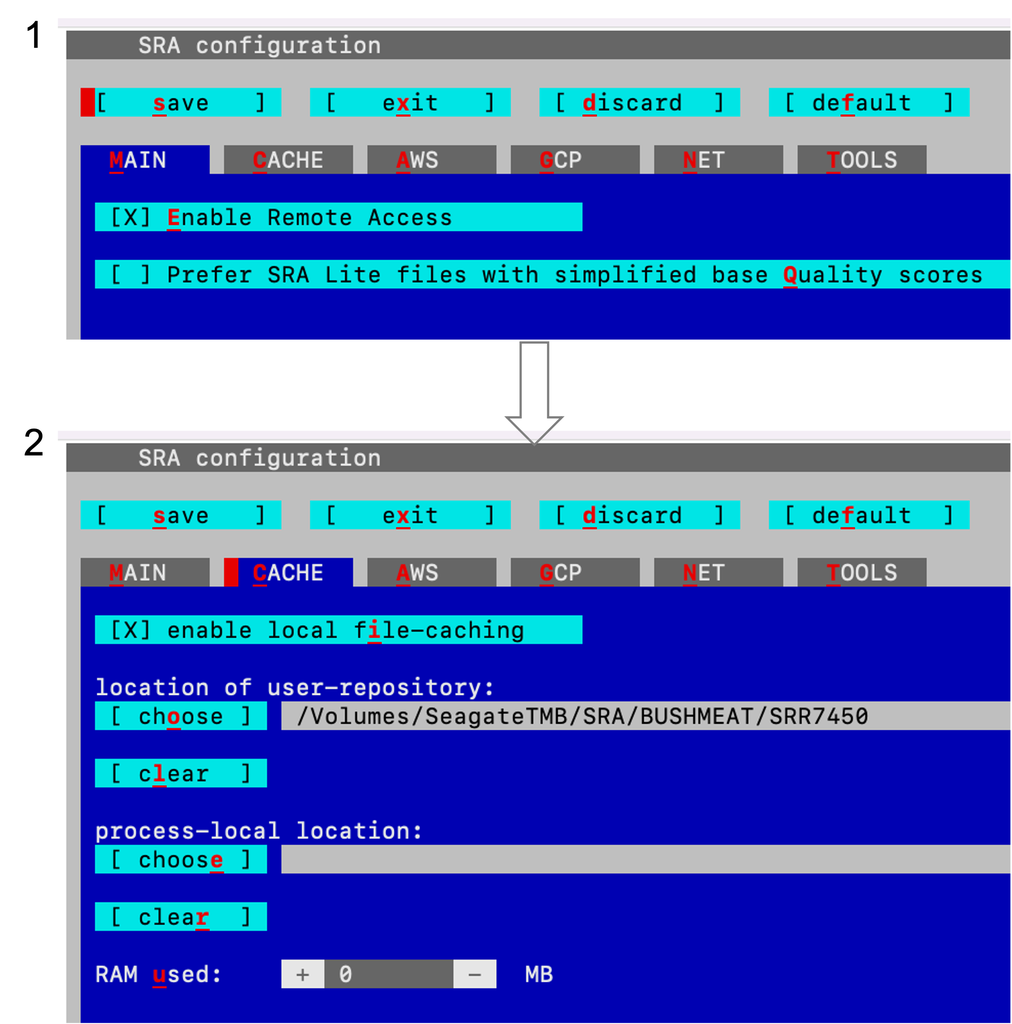

A screenshot of the SRA configuration.

For more information click [here](https://github.com/ncbi/sra-tools/wiki/03.-Quick-Toolkit-Configuration).

## Using already installed sratools

We can create an environment and install essential toolkits (Refer [IMAP-PART 01](https://tmbuza.github.io/imap-software-requirements/))

```bash
name: sradb
channels:
  - conda-forge
  - bioconda
dependencies:
  - snakemake =7.19.1
  - snakemake-minimal =7.19.1
  - snakedeploy =0.8.6
  - sra-tools
  - entrez-direct
  - pysradb
  - insilicoseq =1.5.4
  - seqkit =2.3.1
```

```bash
mamba create -bioconda -conda-forge sradb -file environment.yml
```

# Downloading the fastq files

## Using fasterq-dump

- Be sure that the `fasterq-dump` is in the path.
- Type `which fasterq-dump` to confirm if is in the path.
- Use the absolute path like `~/sratoolkit.3.0.0-mac64/bin/fasterq-dump` if the executable file is not in the path.
- The example below uses absolute path to execute the `fasterq-dump` command.

> In this demo the sratoolkit `~/sratoolkit.3.0.0-mac64` folder is in the home directory. Notice that the output and temporary files are placed in an external volume mounted to the computer.

```bash
for (( i = 706; i <= 761; i++ ))
    do
        time ~/sratoolkit.3.0.0-mac64/bin/fasterq-dump SRR7450$i \
        -O /Volumes/SeagateTMB/SRA/BUSHMEAT/SRR7450/ \
        -t /Volumes/SeagateTMB/SRA/BUSHMEAT/SRR7450/tmpfiles \
        --threads 4 \
        --split-3;
    done
```

# How to resize Fastq files

## Example

> This example extract 1% of the reads in only two sample (SRR10245277 & SRR10245278)

```bash
mkdir -p data
for i in {77..78}
  do
    cat SRR102452$i\_R1.fastq \
    | seqkit sample -p 0.01 \
    | seqkit shuffle -o data/SRR102452$i\_R1_sub.fastq \
    | cat SRR102452$i\_R2.fastq \
    | seqkit sample -p 0.01 \
    | seqkit shuffle -o data/SRR102452$i\_R2_sub.fastq
  done
```

# Related work

[output not shown]

## Citation

> Please consider citing the iMAP article<sup>[1]</sup> if you find any part of the IMAP practical user guides helpful in your microbiome data analysis.

# References

[1]

Buza, T. M., Tonui, T., Stomeo, F., Tiambo, C., Katani, R., Schilling, M., … Kapur, V. (2019). iMAP: An integrated bioinformatics and visualization pipeline for microbiome data analysis. *BMC Bioinformatics*, *20*. https://doi.org/10.1186/S12859-019-2965-4

# Appendix

## Project main tree

```
.
├── LICENSE
├── PRJNA477349-info.tsv
├── README.md
├── config
│   ├── config.yaml
│   ├── samples.tsv
│   └── units.tsv
├── dags
│   ├── rulegraph.png
│   └── rulegraph.svg
├── data
│   ├── metadata
│   ├── reads
│   ├── temp
│   └── test
├── docs
│   └── env_spec_file.txt
├── images
│   ├── bkgd.png
│   ├── cicd.png
│   ├── smkreport
│   └── sra_config_cache.png
├── index.Rmd
├── library
│   ├── apa.csl
│   ├── imap.bib
│   └── references.bib
├── report.html
├── results
│   ├── project_tree.txt
│   └── run_accessions.txt
├── styles.css
└── workflow
    ├── Snakefile
    ├── envs
    ├── rules
    ├── schemas
    └── scripts

17 directories, 21 files
```

## Screenshot of interactive snakemake report

> The interactive snakemake HTML report can be viewed by opening the `report.html` using any compatible browser. You will be able to explore the workflow and the associated statistics. You can close the left bar to get a more expansive display view.

[figure not shown]

## Troubleshooting of FAQs

Last updated on March 13, 2023.  
Github_Repo: https://github.com/tmbuza/imap-download-sra-reads.  
Repo compiled and maintained by: Teresia Mrema-Buza.